# GR5072 Modern Data Structures_HW 4

Bolim Son

October 13, 2019

## **Functions II**

### **1. Functions in the `dplyr` Package**

```r
# Get all of the functions in dplyr
content <- mget(ls("package:dplyr"), inherits = TRUE)
dplyr_functions <- Filter(is.function, content)
```

**a) Longest name**

Use the appropriate map function to produce a vector of the names of all functions in the dplyr package. Which function has the longest name?

```r
# Load library
library(purrr)

# Produce a vector of the names of all functions in dplyr package
dplyr_function_names <- names(dplyr_functions) %>%
  map_chr(paste) %>%
  map(vector(mode = "character"))

# Return longest name
dplyr_function_names[nchar(dplyr_function_names) == max(nchar(dplyr_function_names))]
```

```
## [[1]]
## [1] "group_by_drop_default"
```

**b) Number of arguments**

Use the appropriate map function to calculate the number of arguments by function. Present a table of the Top 10 functions with the most arguments. Which function has the most arguments? Hint: Remember that the functions formals(), body(), and environment() allow you to access parts of a function.

```r
# Get the number of arguments in each function
n_arguments_list <- dplyr_functions %>%
  map(formals) %>% # extract agruments
  map_int(length) %>% # number arguments
  sort(decreasing = TRUE) # sort


# Functions with most number of arguments
n_arguments_list[1:10]
```

```
##      sql_select       nest_join        sql_join       all_equal
##              10               7               7               6
##   compare_tbls2           count db_create_index  db_write_table
##               6               6               6               6
##         enexprs          enquos
##               6               6
```

**c) Most common argument** Which function arguments are the top 5 most common? Briefly explain what the most common argument does.

```r
# Get agruments in dyplr_functions
common_agruments <- dplyr_functions %>%
  map(formalArgs) %>%
  unlist()%>%
  map_chr(paste)%>%
  as.vector()%>%
  as.data.frame.character()

# Arrange the top 5 most common arguments
common_agruments_5 <- common_agruments%>%
  rename(arguments = ".")%>%
  group_by(arguments)%>%
  summarise(counts = n())%>%
  arrange(desc(counts)) %>%
  head(5)

# Return the 5 most common arguments
common_agruments_5
```

| arguments | counts |
| --- | --- |
| ... | 150 |
| x | 83 |
| .tbl | 38 |
| .data | 33 |
| .funs | 27 |

- Brief explanation of the 5 most common arguments:
  - `...` is not specified part where additioanl arguments can be passed down in a function.
  - `x` refers to data to which the function will be applied to. `x` can be a tbl, vector, list etc.
  - `.data` refers to data to which the function will be applied to. For example, in the function `arrange(.data, ...)`, `.data` argument refers to a tbl where `arrange()` will be applied.
  - `.tbl` refers to a tbl to which the function will be applied to.
  - `.funs` refers to functions, so if this is written, you need to type a function that will be used.

### **2. Infant Mortality and GPD per Capita**

**a) Highest and lowest infant mortality rates in 2018**

Use the WDI package to obtain country-year data on infant mortality and GDP per capita from the World Bank database.

The indicator short names in the World Development Indicators are: NY.GDP.PCAP.PP.KD - GDP per capita, PPP (constant 2005 international), SP.DYN.IMRT.IN - Mortality rate, infant (per 1,000 live births). Make sure to obtain information about the region of the country as well (using the extra=TRUE option in the WDI() command). Specify the requested range of years from 1960 to 2018.

```r
# Load WDI package
library(WDI)

# Load dataset
WDI_raw <- WDI(country = "all", indicator = c("NY.GDP.PCAP.PP.KD", "SP.DYN.IMRT.IN"), start = 1960, end = 2018, extra = TRUE)
```

Rename the variables: infant mortality (infmort) and GPD per capita (gdpcap). Keep only entries for countries (i.e. remove entries for regions and the World as a whole).

```r
# Clean dataset, rename variables
WDI_clean <- WDI_raw %>%
  filter(region != "Aggregates") %>%
  select(country:SP.DYN.IMRT.IN, region) %>%
  rename(infmort = SP.DYN.IMRT.IN, gdpcap = NY.GDP.PCAP.PP.KD)%>%
  filter(!is.na(gdpcap),!is.na(infmort)) %>%
  mutate(gdpcap = as.numeric(gdpcap))

# Check dataset
WDI_clean_check <- rbind(head(WDI_clean), tail(WDI_clean))
WDI_clean_check
```

|  | country | year | gdpcap | infmort | region |
| --- | --- | --- | --- | --- | --- |
| 1 | United Arab Emirates | 1998 | 100904.475 | 10.2 | Middle East & North Africa |
| 2 | United Arab Emirates | 1999 | 98483.118 | 9.9 | Middle East & North Africa |
| 3 | United Arab Emirates | 2000 | 103318.150 | 9.6 | Middle East & North Africa |
| 4 | United Arab Emirates | 2006 | 87120.065 | 8.1 | Middle East & North Africa |
| 5 | United Arab Emirates | 2007 | 77235.854 | 7.9 | Middle East & North Africa |
| 6 | United Arab Emirates | 2008 | 69351.020 | 7.6 | Middle East & North Africa |
| 5162 | Zimbabwe | 2013 | 2491.635 | 42.8 | Sub-Saharan Africa |
| 5163 | Zimbabwe | 2014 | 2506.490 | 40.4 | Sub-Saharan Africa |
| 5164 | Zimbabwe | 2015 | 2509.008 | 38.5 | Sub-Saharan Africa |
| 5165 | Zimbabwe | 2016 | 2489.097 | 36.3 | Sub-Saharan Africa |

[output cut: 2 more lines]

```r
rm(WDI_clean_check)

n_distinct(WDI_clean$country)
```

```
## [1] 186
```

Present a list of countries with the 5 highest and the 5 lowest infant mortality rates in 2018 along with their GDP per capita in that year.

```r
# Create a dataframe of mortality rates in 2018
mortality_df <- WDI_clean %>%
  filter(year == 2018) %>%
  arrange(desc(infmort)) %>%
  select(-year, -region)

# Create a list of countries with the 5 highest and 5 lowest infant mortality rates in 2018 with their GDP per capita
mortality_list <- rbind(head(mortality_df,5), tail(mortality_df,5)) %>%
  map(as.vector) %>%
  transpose()

# Print the list
mortality_list
```

```
## [[1]]
## [[1]]$country
## [1] "Central African Republic"
##
## [[1]]$gdpcap
## [1] 774.6877
##
## [[1]]$infmort
## [1] 84.5
##
##
## [[2]]
## [[2]]$country
## [1] "Sierra Leone"
##
## [[2]]$gdpcap
## [1] 1425.342
##
## [[2]]$infmort
## [1] 78.5
##
##
## [[3]]
## [[3]]$country
## [1] "Nigeria"
##
## [[3]]$gdpcap
## [1] 5315.823
##
## [[3]]$infmort
## [1] 75.7
##
##
## [[4]]
## [[4]]$country
## [1] "Chad"
##
## [[4]]$gdpcap
## [1] 1746.482
##
```

[output cut: 53 more lines]

```
## [1] 48605.58
##
## [[9]]$infmort
## [1] 1.5
##
##
## [[10]]
## [[10]]$country
## [1] "Finland"
##
## [[10]]$gdpcap
## [1] 41782.07
##
## [[10]]$infmort
## [1] 1.4
```

**b) Overall regression**

Run an overall regression predicting infant mortality from GDP per capita. What do you find? Make a scatter plot (including a regression fit line).

```r
# Remove NA
library(ggplot2)

# Run regression
lm(infmort~gdpcap, WDI_clean)
```

```
##
## Call:
## lm(formula = infmort ~ gdpcap, data = WDI_clean)
##
## Coefficients:
## (Intercept)       gdpcap
##  47.9645148   -0.0009188
```

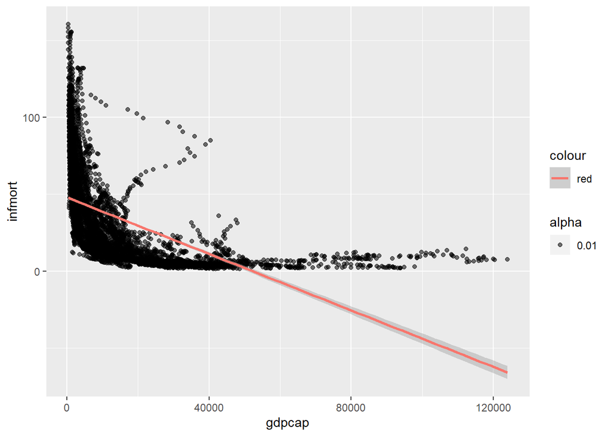

```r
# Draw plot and regression line
WDI_plot <- WDI_clean %>%
  filter(!is.na(gdpcap), !is.na(infmort)) %>%
  ggplot(mapping = aes(x = gdpcap, y = infmort)) +
  geom_point(aes(alpha = 0.01)) +
  geom_smooth(method = lm, aes(color = "red"))


WDI_plot
```

**c) Regression by region**

Let’s see if the overall relationship holds within world regions. Split the the data by region and create a nested list that contains these split data frames. In a single pipeline, re-estimate the regression for each of these data frames, obtain the coefficient estimates for the slope for each region and present them in a table (sorted by size of the coefficient).

```r
# Regression by region in a list
WDI_lm_region <- WDI_clean %>%
  split(WDI_clean$region, drop = TRUE) %>% # nested list by region
  map(~lm(infmort ~ gdpcap, data =.)) %>% # regression
  map(~coef(.))%>%
  map("gdpcap")%>%
  map_dfr(sort)%>%
  tidyr::gather() %>%
  rename(Regions = key, Slope_coefficient = value)

# Table
WDI_lm_region
```

| Regions | Slope_coefficient |
| --- | --- |
| East Asia & Pacific | -5.842906e-04 |
| Europe & Central Asia | -4.897775e-04 |
| Latin America & Caribbean | -1.152157e-03 |
| Middle East & North Africa | -2.757224e-04 |
| North America | -1.470118e-05 |
| South Asia | -5.767946e-03 |
| Sub-Saharan Africa | -2.260253e-03 |

**d) Regression by country**

Let’s also check if the relationship is consistent if estimated within countries. Split the overall data by country and create a nested list that contains these split data frames.

Again, estimate a simple linear regression, predicting infant mortality by GDP per capita. In what percentage of the within-country regressions do we find a positive relationship (at the 95% confidence level) between GDP per capita and infant mortality?

```r
# Create a nested list split by countries
WDI_country_split <- WDI_clean %>%
  split(WDI_clean$country)

# A dataframe of slope coefficients
WDI_slope <- WDI_country_split %>%
  map(~lm(infmort ~ gdpcap, data = .)) %>%
  map(summary) %>%
  map(~ coef(.)) %>%
  map_dfr(`[`, 2) %>% # subset slope coefficients
  tidyr::gather() %>%
  rename(slope = value, country = key) # rename

# A dataframe of p values
WDI_confintv <- WDI_country_split %>%
  map(~lm(infmort ~ gdpcap, data = .)) %>%
  map(summary) %>%
  map(~ coef(.)) %>%
  map_dfr(`[`, 8) %>% # subset p values
  tidyr::gather() %>%
  rename(confintv = value, country = key) # rename

# Dataframe for all countries of its slopes and confidence intervals
WDI_regression_all <- merge(WDI_slope, WDI_confintv) %>%
  filter(!is.na(slope), !is.na(confintv)) %>%
  mutate(slope = as.numeric(.$slope), confintv = as.numeric(.$confintv))

# Filter countries with positive slope coefficients at 95% confidence interval
WDI_regression_positive <- WDI_regression_all %>%
  filter(slope > 0, confintv <= 0.05)

# Percentage of countries with positive relationship between GDP per capita and infant mortality
nrow(WDI_regression_positive) / nrow(WDI_regression_all) * 100
```

```
## [1] 4.864865
```

- At 95% confidence level, 4.86 % of countries have positive relationship between GDP per capita and infant mortality

Make a histogram of the slope coefficients to illustrate the variation of the estimated relationship.

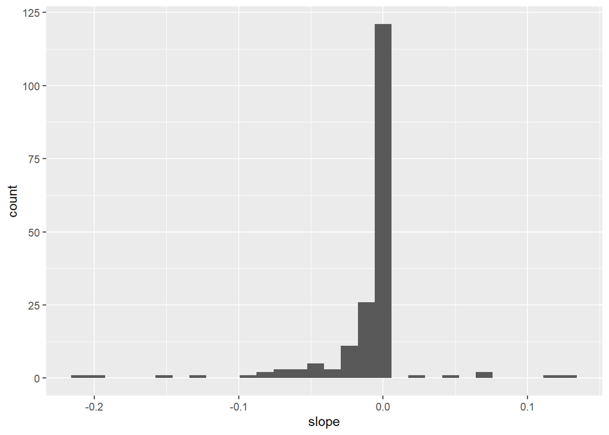

```r
# Histogram of slope coefficients
library(ggplot2)

WDI_slope %>%
  filter(!is.na(slope)) %>%
  ggplot()+
  geom_histogram(mapping = aes(x = slope))
```

Which country cases are most at odds with the overall regression estimated in part (b)?

```r
# Compare slope coefficient of each country with overall regression (-0.0009188)
# Absolute value
WDI_regression_compare <- WDI_regression_all %>%
  mutate(comparison = abs(slope -(-0.0009188))) %>%
  arrange(desc(comparison))

# Return country with most difference in slope coefficient
WDI_regression_compare[1, c(1,4)]
```

|  | country | comparison |
| --- | --- | --- |
| 1 | Malawi | 0.2102391 |

- Country with most at odds with overall regression in terms of slope coefficient is Malawi.

**e) Added squared term**

Let’s see if we can improve the models slightly. Using the list of country data frames from (d), estimate regressions of infant mortality on GDP per capita and the square of GDP per capita. Compare the adjusted R-Squareds of the models with and without the added squared term of GDP per capita. Provide the average model adjusted R-squared with and without the squared term. Would you recommend to keep the squared term or not?

```r
# Linear regression with GDP per capita only
gdpcap_1 <- WDI_country_split %>%
  map(~lm(infmort~gdpcap, data=.)) %>%
  map(summary) %>%
  map("adj.r.squared")

mean(as.numeric(gdpcap_1))
```

```
## [1] 0.6619114
```

```r
# Linear regression with GDP per capita and its squared value
gdpcap_2 <- WDI_country_split%>%
  map(~lm(infmort ~ gdpcap + map_dbl(gdpcap, function(i)(i^2)), data=.))%>%
  map(summary)%>%
  map("adj.r.squared")

mean(as.numeric(gdpcap_2))
```

```
## [1] 0.7516651
```

```r
# Compare two model means

mean(as.numeric(gdpcap_1)) - mean(as.numeric(gdpcap_2))
```

```
## [1] -0.08975368
```

- Comparison of the two models show that squared term has approximately 9% increase, so adding the squared term will be a better answer.